# RFM analysis

GEORGE KNOX

Computer Lab 2

### Introduction

**RFM**, recency (**R**), frequency (**F**) and monetary value (**M**) are the most often used database marketing metrics used to quantify customer transaction history. RFM analysis segments customer into groups according to these measures and relates these segments to the likelihood of responding to a marketing offer. This notebook discusses the measures, segmentation, usefulness for guiding marketing decisions, and extensions to the basic model.

### Installing the packages and loading the data

To illustrate the technique, we are going to use data from eBeer.

```r
rm(list = ls())

options("scipen"=100, "digits"=3)

library(data.table)
library(gtools)
library(dplyr)
library(VGAM)

# set your working directory
# write the path where the folder containing the files is located
# setwd("/Users/munyikz/Documents/tutorial")
setwd("/Users/gknox/Dropbox/Customer Analytics/R notebooks/RFM & logistic")

ebeer<-read.csv('data/ebeer.csv')

# set working directory as wherever this .rmd file is saved
# Note: comment this line out below if you want to knit the full doc.
```

### Inspecting the data

We talked about the `ebeer` dataset last computer lab.

```r
head(ebeer)
```

```
##   ï..acctnum gender  R  F     M firstpur age_class single student mailing
## 1      10001      1 30 10  35.7       50         3      1       1       1
## 2      10005      0 16  1 149.0       16         0      0       1       1
## 3      10010      0 12  1 123.0       12         0      1       0       1
## 4      10011      0  6  2 147.0        8         0      1       1       1
## 5      10014      1  6  3  96.0       18         0      0       1       1
## 6      10020      0 12  2 150.5       14         0      1       1       1
##   respmail
## 1        0
## 2        0
## 3        0
## 4        0
## 5        1
## 6        0
```

```r
summary(ebeer)
```

```
##    ï..acctnum        gender            R              F               M
##  Min.   :10001   Min.   :0.000   Min.   : 2.0   Min.   : 1.00   Min.   : 15.0
##  1st Qu.:22351   1st Qu.:0.000   1st Qu.: 8.0   1st Qu.: 1.00   1st Qu.: 33.8
##  Median :34888   Median :0.000   Median :12.0   Median : 2.00   Median : 63.0
##  Mean   :34865   Mean   :0.299   Mean   :13.2   Mean   : 3.89   Mean   : 92.0
##  3rd Qu.:47524   3rd Qu.:1.000   3rd Qu.:16.0   3rd Qu.: 6.00   3rd Qu.:131.5
##  Max.   :59993   Max.   :1.000   Max.   :36.0   Max.   :12.00   Max.   :314.0
##
##     firstpur      age_class        single         student        mailing
##  Min.   : 2.0   Min.   :0.00   Min.   :0.000   Min.   :0.00   Min.   :0.000
##  1st Qu.:12.0   1st Qu.:0.00   1st Qu.:0.000   1st Qu.:0.00   1st Qu.:0.000
##  Median :20.0   Median :1.00   Median :0.000   Median :1.00   Median :0.000
##  Mean   :26.5   Mean   :0.85   Mean   :0.305   Mean   :0.53   Mean   :0.497
##  3rd Qu.:36.0   3rd Qu.:1.00   3rd Qu.:1.000   3rd Qu.:1.00   3rd Qu.:1.000
##  Max.   :99.0   Max.   :8.00   Max.   :1.000   Max.   :1.00   Max.   :1.000
##
##     respmail
##  Min.   :0
##  1st Qu.:0
##  Median :0
##  Mean   :0
##  3rd Qu.:0
##  Max.   :1
##  NA's   :5012
```

Each row is a customer. Acctnum is their id. We have gender, Recency (the number of months since the last purchase), Frequency (number of purchases), M (average amount spent per purchase), first purchase (number of months since first purchase), age, single, student, whether they received a mailing, did they respond.

Let’s look at the marketing variable: who gets a mailing in this dataset?

```r
table(ebeer$mailing)
```

```
##
##    0    1
## 5012 4952
```

How many people of those mailed respond?

```r
ebeer %>%
  group_by(mailing) %>% summarize(mean=mean(respmail), n=n())
```

```
## # A tibble: 2 x 3
##   mailing   mean     n
##     <int>  <dbl> <int>
## 1       0 NA      5012
## 2       1  0.124  4952
```

There is only a response if someone gets a mailing in the first place.

```r
table(ebeer$mailing, ebeer$respmail)
```

```
##
##        0    1
##   0    0    0
##   1 4336  616
```

We have to tell it to show us if there are any NA’s.

```r
table(ebeer$mailing, ebeer$respmail, useNA = "ifany")
```

```
##
##        0    1 <NA>
##   0    0    0 5012
##   1 4336  616    0
```

### Binomial model for responses

The probability of observing $s$ people respond out of $n$ people mailed is described by a binomial distribution:
$$P(s|n, p) = {n \choose s} p^{s}
(1-p)^{n-s}$$
It has one parameter, $p$, the probability of response. The maximum likelihood estimate is of $p$ is
$$\hat{p} = \frac{s}{n} = \frac{\# \;
\textrm{successes}}{\# \; \textrm{trials}}$$
What is $s$, $n$ and $\hat{p}$ in our data?

- $s$ is the number of responses (or successes), 616.
- $n$ is the total number of people mailed, 4952.
- Therefore $\hat{p}$, the overall response rate (probability of response):

```r
p_hat<-mean(ebeer$respmail[ebeer$mailing==1])
p_hat
```

```
## [1] 0.124
```

The standard error of the proportion is $\sqrt{\frac{\hat{p}(1-\hat{p})}{n}}$, and the 95% confidence interval is calculated as follows.

```r
n = sum(ebeer$mailing==1)
p_hat_se = sqrt(p_hat*(1-p_hat)/n) #standard error of estimate p

qnorm(c(0.025, 0.975), mean=p_hat, sd=p_hat_se)
```

```
## [1] 0.115 0.134
```

### Creating R, F and M segments separately.

Let’s look at the distribution of raw RFM variables.

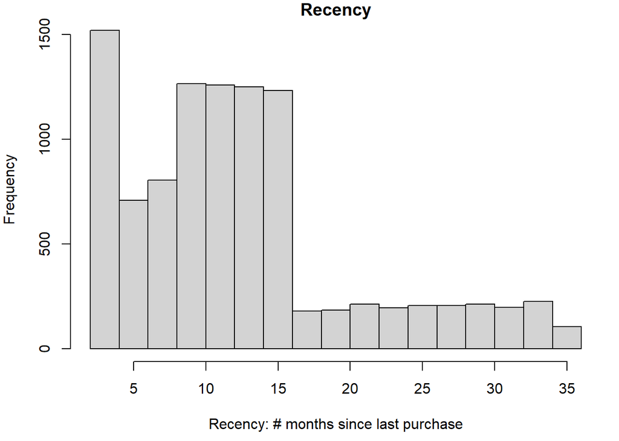

```r
ebeer$F<-as.numeric(ebeer$F)
par(mai=c(.9,.8,.2,.2))
hist(ebeer$R, main="Recency", xlab="Recency: # months since last purchase")
```

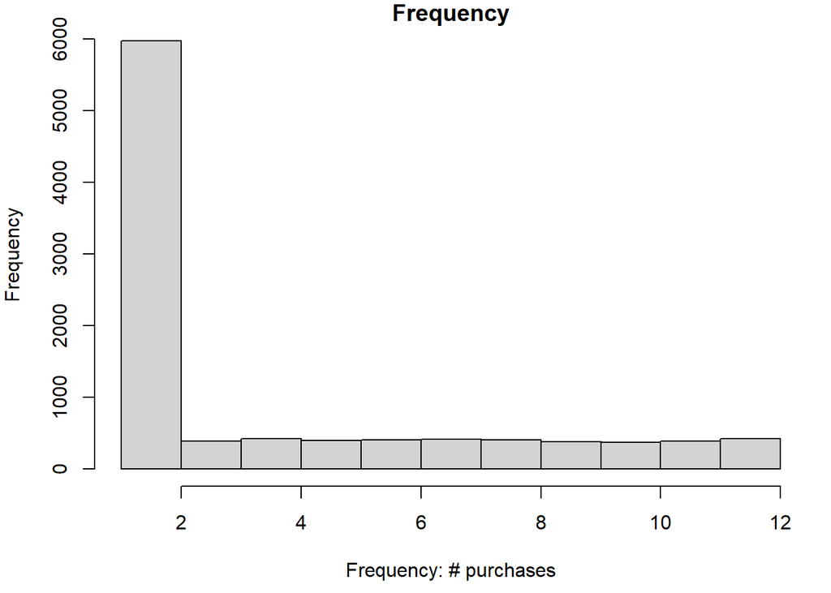

```r
hist(ebeer$F, main="Frequency", xlab="Frequency: # purchases")
```

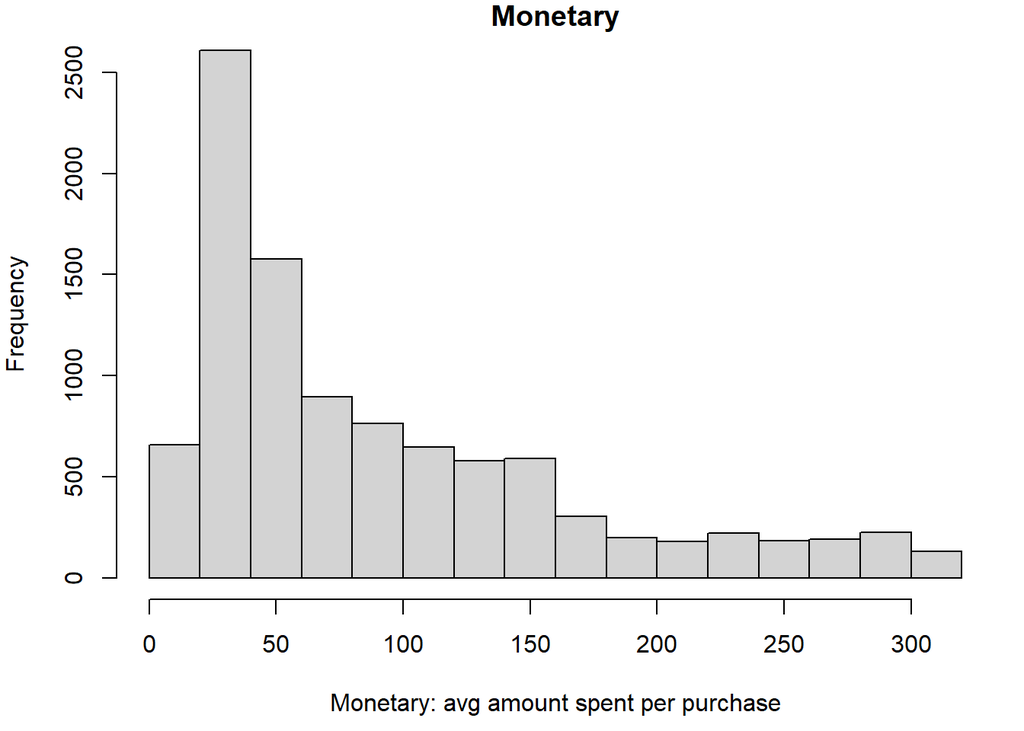

```r
hist(ebeer$M, main="Monetary", xlab="Monetary: avg amount spent per purchase")
```

Let’s first create segments from each variable separately; we create separate segments for R, F, and M. We sort them from largest to smallest. Then we create $n$ bins, where $n=5$

```r
ebeer$Rgroup<-quantcut(x = ebeer$R, q=5)

table(ebeer$Rgroup)
```

```
##
##   [2,6]  (6,10] (10,14] (14,16] (16,36]
##    2229    2069    2509    1231    1926
```

How many are in each quantile? It should be about the same, but exceptions because of ties: many customers share the same value.

```r
table(ebeer$R)
```

```
##
##    2    4    6    8   10   12   14   16   18   20   22   24   26   28   30   32
##  746  774  709  804 1265 1259 1250 1231  179  185  212  196  205  206  213  198
##   34   36
##  226  106
```

If we had a continuous random variable, there would be no ties (a clump of customers with the same F): every group would have exactly the same number of observations.

```r
test<-rnorm(1000)
test_group<-quantcut(x=test,q=5, labels=FALSE)
table(test_group)
```

```
## test_group
##   1   2   3   4   5
## 200 200 200 200 200
```

Next, we look at the average recencey (time since last purchase) per R group. Group 1 has the lowest (most recent), 5 the highest (least recent).

```r
ebeer %>%
  group_by(Rgroup) %>% summarize(mean=mean(R), sd=sd(R), n=n())
```

```
## # A tibble: 5 x 4
##   Rgroup   mean    sd     n
##   <fct>   <dbl> <dbl> <int>
## 1 [2,6]    3.97 1.62   2229
## 2 (6,10]   9.22 0.975  2069
## 3 (10,14] 13.0  1.00   2509
## 4 (14,16] 16    0      1231
## 5 (16,36] 26.8  5.46   1926
```

```r
#
# aggregate(ebeer$R,list(ebeer$Rgroup), mean, na.rm="TRUE") # an alternative without using pipes.
```

Now, let’s examine how response rate vary with the recency groups we just created. We only want to look at the subset of customer who were mailed, so we filter the dataset first `filter(mailing==1)`. We group by our just created 5 R segments. And we calculate the mean of response, `mean(respmail)`.

```r
ebeer %>% filter(mailing==1)%>% group_by(Rgroup) %>% summarize(mean=mean(respmail), sd=sd(respmail), n=n())
```

```
## # A tibble: 5 x 4
##   Rgroup   mean    sd     n
##   <fct>   <dbl> <dbl> <int>
## 1 [2,6]   0.126 0.332  1098
## 2 (6,10]  0.119 0.324  1041
## 3 (10,14] 0.122 0.328  1211
## 4 (14,16] 0.136 0.343   632
## 5 (16,36] 0.124 0.329   970
```

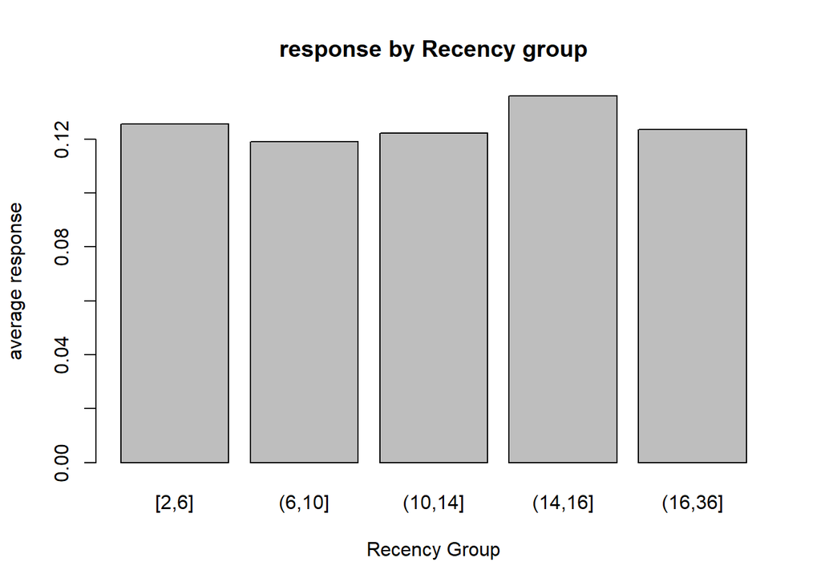

```r
# assign it to variable respR
respR<-ebeer %>% filter(mailing==1)%>% group_by(Rgroup) %>% summarize(mean=mean(respmail), sd=sd(respmail), n=n())


barplot(respR$mean~respR$Rgroup, main="response by Recency group", xlab="Recency Group", ylab="average response")
```

### Comprehension Check

> *Repeat this analysis for frequency. Based on these graphs, which has more of an impact on the response rate: R or F?*

> [DISCUSS HERE]

### Full RFM analysis

Now do the full RFM analysis. Remember, the idea is that

1. We first sort by R, create segments. (we already did this.)
2. Within each R segment, we sort F and create RF segments.
3. Within each RF segment, we sort M and create RFM segments.

The way to do this is slightly complicated; I would give you this script in an exam or assignment. You would not have to code this up yourselves. First, we change ebeer into data.table Within each R group, we create F groups -> RF groups. Within each RF group, we create M groups -> RFM groups

```r
ntiles <- function(x, bins) {
  quantiles = seq(from=0, to = 1, length.out=bins+1)
  cut(ecdf(x)(x),breaks=quantiles, labels=F)
}

ebeer$Rgroup <- ntiles(ebeer$R, bins=5)


dt = data.table(ebeer)
nbins = 5
dt[, RFgroup := paste0(as.character(Rgroup), as.character(ntiles(F, bins = nbins))), by = c('Rgroup')]
dt[, RFMgroup := paste0(as.character(RFgroup), as.character(ntiles(M, bins = nbins))), by = c('RFgroup')]

# put it back to data.frame
ebeer = data.frame(dt)

# change it to a factor variable
ebeer$RFMgroup<-as.factor(ebeer$RFMgroup)
```

How many RFM groups do we get with this procedure? (What would be the maximum number we could possibly get?)

```r
length(unique(ebeer$RFMgroup))
```

```
## [1] 90
```

How many are in each group?

```r
table(ebeer$RFMgroup)
```

```
##
## 121 122 123 124 125 131 132 133 134 135 141 142 143 144 145 151 152 153 154 155
##  87  89  89  88  89  85  87  87  86  87  66  66  67  66  67  62  63  63  63  63
## 221 222 223 224 225 231 232 233 234 235 241 242 243 244 245 251 252 253 254 255
##  87  89  87  89  89  92  91  93  92  93  51  52  51  52  52  69  72  69  72  71
## 321 322 323 324 325 341 342 343 344 345 351 352 353 354 355 421 422 423 424 425
## 155 156 154 153 160 232 231 230 233 235 115 119 117 117 117  77  77  76  78  77
## 431 432 433 434 435 441 442 443 444 445 451 452 453 454 455 521 522 523 524 525
##  71  72  72  73  73  46  47  46  48  47  53  55  54  54  54 186 186 185 190 187
## 541 542 543 544 545 551 552 553 554 555
## 296 291 300 292 303 147 149 146 150 149
```

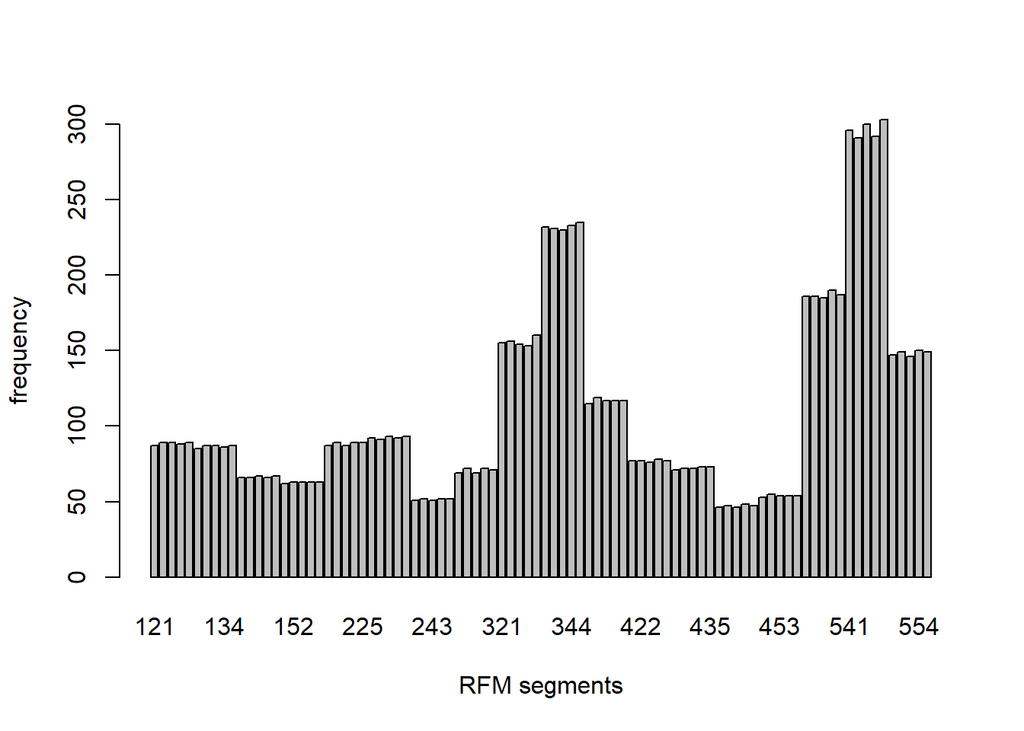

```r
barplot(table(ebeer$RFMgroup), xlab = "RFM segments", ylab="frequency")
```

### Response rate by RFM segment

How does response vary across RFM groups? In RFM analysis, we fit a separate binomial model to every segment in the data. Our estimates of the segment specific response rates are
$$\hat{p}_z = \frac{s_z}{n_z}$$
here $s_z$ is the number of responses in segment $z$ and $n_z$ is the number of people mailed.

Let’s make the response rate by segment. We use `mutate` to create a new variable, `resp_rate`.

```r
# tally up number of mailings (n_mail) and responses (n_resp) by RFM group; remove na for responses.
# create a response rate fraction by taking n_resp/n_mail

ebeer %>% group_by(RFMgroup) %>% summarize(n_resp=sum(respmail, na.rm = TRUE), n_mail=sum(mailing,na.rm = TRUE)) %>% mutate(resp_rate = n_resp/n_mail) %>% print(n=90)
```

```
## # A tibble: 90 x 4
##    RFMgroup n_resp n_mail resp_rate
##    <fct>     <int>  <int>     <dbl>
##  1 121           0     39    0
##  2 122           0     48    0
##  3 123           0     46    0
##  4 124           0     45    0
##  5 125           0     38    0
##  6 131           0     43    0
##  7 132           4     47    0.0851
##  8 133           2     40    0.05
##  9 134           4     46    0.0870
## 10 135           4     39    0.103
## 11 141           7     37    0.189
## 12 142           5     36    0.139
```

[output cut: 78 more lines]

```r
# set it equal to respRFM

respRFM<-
ebeer %>% group_by(RFMgroup) %>% summarize(n_resp=sum(respmail, na.rm = TRUE), n_mail=sum(mailing,na.rm = TRUE)) %>% mutate(resp_rate = n_resp/n_mail)
```

### Comprehension Check

> *What is the response rate of segment 442?*

> [DISCUSS HERE]

### Targeting using RFM analysis

Now let’s figure out which segments we should target. We want to target segments that have a response rate above the breakeven point. Remember the breakeven probability:
$$\bar{p}_{BE} = \frac{c}{m} = \frac{\textrm{cost}}{\textrm{margin}}$$
where $c$ is the cost of marketing/mailing, and $m$ is the profit (margin) if the customer responds.

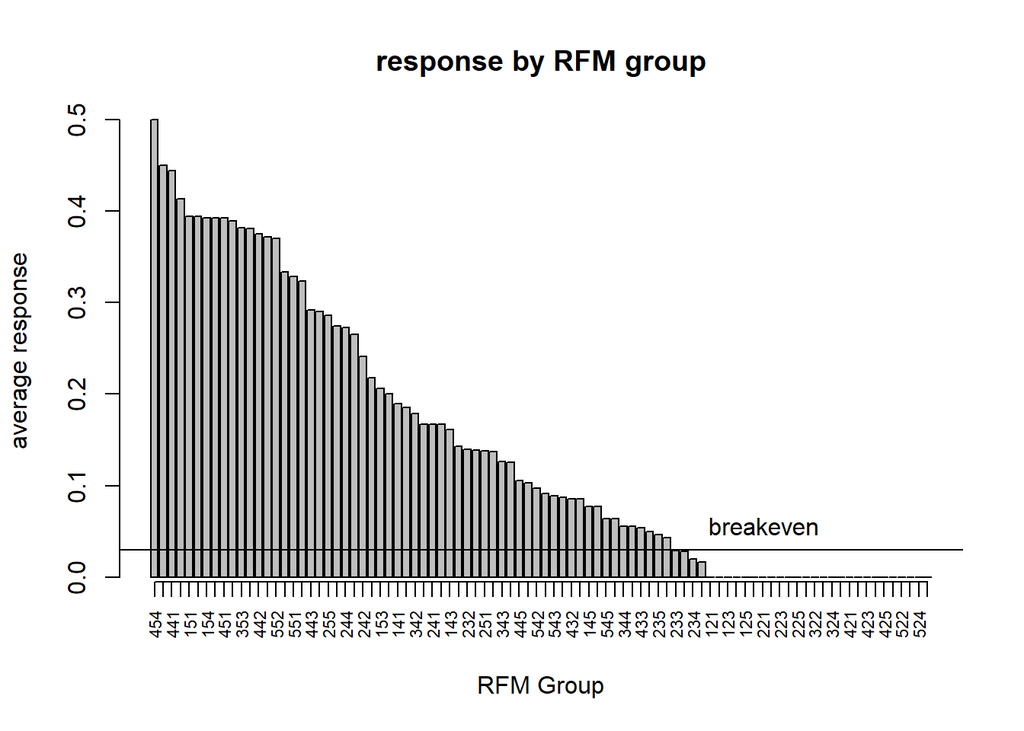

```r
# re-order from most to least, make picture better

respRFM<-respRFM %>% arrange(desc(resp_rate))

# calculate breakeven line

c = 1.5
m = 50
brk = c/m

respRFM<-as.data.frame(respRFM)

bp<-barplot(respRFM[,4], main="response by RFM group", xlab="RFM Group", ylab="average response", xaxt="n")
axis(1, at = bp[,1], labels=respRFM[,1], cex.axis=0.7, las=2)

abline(h=brk)
text(85, brk, "breakeven", cex=1, pos=3, col="black")
```

How many segments are above the breakeven, and therefore targeted? What segments are they? As a percentage of the total segments?

```r
# how many segments above breakeven?
sum(respRFM$resp_rate >= brk)
```

```
## [1] 60
```

```r
# which segments?
list(respRFM[respRFM$resp_rate >= brk, 1])
```

```
## [[1]]
##  [1] 454 453 441 152 151 252 154 155 451 555 353 355 442 553 552 554 551 253 443
## [20] 254 255 354 244 352 242 351 153 452 141 455 342 144 241 341 143 245 232 142
## [39] 251 541 343 243 445 135 542 444 543 134 432 132 145 435 545 231 344 434 433
## [58] 133 235 544
## 90 Levels: 121 122 123 124 125 131 132 133 134 135 141 142 143 144 145 ... 555
```

```r
# as a percentage of all segments
sum(respRFM$resp_rate >= brk) / length(unique(ebeer$RFMgroup))
```

```
## [1] 0.667
```

OK, now let’s apply this model to those customers who have not been mailed, sometimes called the “rollout” sample.

First let’s fit a basic linear model where the dependent variable is the response (0,1) is a function of what RFM group someone is in.

$$\textrm{Response}_i = \alpha + \sum_z \beta_z 1\{\textrm{RFM}_i =z \} +
\epsilon_i$$

The $\hat{\beta}_z$ will be the mean response rate of each segment.

```r
RFM_model <- lm(respmail ~ RFMgroup, data = ebeer)

# print(summary(RFM_model))

# for presentation
summ <- summary(RFM_model)
summ$coefficients <- round(summ$coefficients, 4)
summ$residuals <- round(summ$residuals, 4)
summ
```

```
##
## Call:
## lm(formula = respmail ~ RFMgroup, data = ebeer)
##
## Residuals:
##     Min      1Q  Median      3Q     Max
## -0.5000 -0.1370 -0.0432  0.0000  0.9835
##
## Coefficients:
##             Estimate Std. Error t value            Pr(>|t|)
## (Intercept)   0.0000     0.0486    0.00              1.0000
## RFMgroup122   0.0000     0.0655    0.00              1.0000
## RFMgroup123   0.0000     0.0661    0.00              1.0000
## RFMgroup124   0.0000     0.0664    0.00              1.0000
## RFMgroup125   0.0000     0.0692    0.00              1.0000
## RFMgroup131   0.0000     0.0671    0.00              1.0000
## RFMgroup132   0.0851     0.0658    1.29              0.1958
## RFMgroup133   0.0500     0.0683    0.73              0.4644
## RFMgroup134   0.0870     0.0661    1.32              0.1884
## RFMgroup135   0.1026     0.0688    1.49              0.1359
## RFMgroup141   0.1892     0.0697    2.71              0.0067 **
## RFMgroup142   0.1389     0.0702    1.98              0.0479 *
## RFMgroup143   0.1613     0.0731    2.21              0.0273 *
## RFMgroup144   0.1667     0.0702    2.37              0.0176 *
## RFMgroup145   0.0769     0.0688    1.12              0.2634
## RFMgroup151   0.3939     0.0718    5.48 <0.0000000000000002 ***
## RFMgroup152   0.4138     0.0745    5.56 <0.0000000000000002 ***
## RFMgroup153   0.2059     0.0713    2.89              0.0039 **
## RFMgroup154   0.3929     0.0752    5.22 <0.0000000000000002 ***
## RFMgroup155   0.3929     0.0752    5.22 <0.0000000000000002 ***
## RFMgroup221   0.0000     0.0671    0.00              1.0000
## RFMgroup222   0.0000     0.0649    0.00              1.0000
## RFMgroup223   0.0000     0.0692    0.00              1.0000
## RFMgroup224   0.0000     0.0649    0.00              1.0000
## RFMgroup225   0.0000     0.0671    0.00              1.0000
## RFMgroup231   0.0638     0.0658    0.97              0.3319
## RFMgroup232   0.1395     0.0671    2.08              0.0378 *
## RFMgroup233   0.0286     0.0707    0.40              0.6862
## RFMgroup234   0.0200     0.0649    0.31              0.7579
## RFMgroup235   0.0465     0.0671    0.69              0.4886
```

[output cut: 52 more lines]

```
## RFMgroup543   0.0884     0.0547    1.62              0.1060
## RFMgroup544   0.0432     0.0550    0.78              0.4328
## RFMgroup545   0.0641     0.0544    1.18              0.2384
## RFMgroup551   0.3284     0.0612    5.37 <0.0000000000000002 ***
## RFMgroup552   0.3704     0.0592    6.26 <0.0000000000000002 ***
## RFMgroup553   0.3721     0.0586    6.35 <0.0000000000000002 ***
## RFMgroup554   0.3333     0.0588    5.66 <0.0000000000000002 ***
## RFMgroup555   0.3896     0.0597    6.53 <0.0000000000000002 ***
## ---
## Signif. codes:  0 '***' 0.001 '**' 0.01 '*' 0.05 '.' 0.1 ' ' 1
##
## Residual standard error: 0.304 on 4862 degrees of freedom
##   (5012 observations deleted due to missingness)
## Multiple R-squared:  0.169,  Adjusted R-squared:  0.154
## F-statistic: 11.1 on 89 and 4862 DF,  p-value: <0.0000000000000002
```

### Comprehension Check

> *What is the estimate of segment 442, $\hat{\beta}_{442}$?*

> [DISCUSS HERE]

### Applying predictions to rollout data

We separate the rollout data (where there is no mailing) from everything else. Then, we’ll score the new data, i.e., apply the predictions of the model to the new data.

```r
ebeer.rollout<-ebeer[is.na(ebeer$respmail), ]

ebeer.rollout$RFMpred<-predict(RFM_model,ebeer.rollout)

summary(ebeer.rollout$RFMpred)
```

```
##    Min. 1st Qu.  Median    Mean 3rd Qu.    Max.
##   0.000   0.000   0.085   0.125   0.185   0.500
```

The average prediction is the average response rate we found earlier. So makes sense in terms of face validity.

We now have a probability of response to everyone in the rollout data. How many customers in the rollout would get mailed? as a fraction of the total, what would the profits and return on investment (ROI) be?

$$\textrm{ROI} = \frac{\textrm{total (expected) profits}}{\textrm{total
cost}}$$

```r
# Total number of rollout customers with predicted response rates above breakeven
sum(ebeer.rollout$RFMpred >= brk)
```

```
## [1] 3222
```

```r
# as a proportion of all rollout customers
sum(ebeer.rollout$RFMpred >= brk) / length(ebeer.rollout$RFMpred)
```

```
## [1] 0.643
```

```r
# what would expected profits be of following this strategy?
# profit per customer
# if p > p_BE, expected profit = p*m - c
# if p < p_BE, = 0
ebeer.rollout$RFMprofit <-
  ifelse(ebeer.rollout$RFMpred >= brk, ebeer.rollout$RFMpred *m - c, 0)

# or pmax takes columnwise maximum (same as in L2)
ebeer.rollout$RFMprofit <-
  pmax(ebeer.rollout$RFMpred *m - c, 0)


# sum over customers
sum_profit = sum(ebeer.rollout$RFMprofit)

sum_profit
```

```
## [1] 26109
```

```r
# sum costs of targeting customers
ebeer.rollout$RFMcost <- ifelse(ebeer.rollout$RFMpred >= brk, c, 0)

sum_cost = sum(ebeer.rollout$RFMcost)

# what about the return on investment ROI?
sum_profit / sum_cost
```

```
## [1] 5.4
```

If we targeted everyone in the rollout group:

```r
ebeer.rollout$all <-ebeer.rollout$RFMpred *m - c
sum_profit_all = sum(ebeer.rollout$all)
sum_profit_all
```

```
## [1] 23691
```

```r
sum_cost_all = c*length(ebeer.rollout$RFMpred)
sum_cost_all
```

```
## [1] 7518
```

```r
sum_profit_all / sum_cost_all
```

```
## [1] 3.15
```

### Large standard errors for some response rates

```r
respRFM<-respRFM %>% mutate(n_nonresp = n_mail-n_resp) %>% relocate(n_nonresp, .after=n_resp)
```

```r
seg_431<- respRFM %>% filter(RFMgroup=="431")

p_hat<- seg_431$resp_rate

n = seg_431$n_mail
```

### Comprehension Check

> *What is the confidence interval of the response rate for segment 431?*

> [DISCUSS HERE]

### Using a Bayesian approach

Right now we assume that these segments response rates are entirely independent of each other. In other words, knowing what the overall response rate is tells us nothing about the segment.

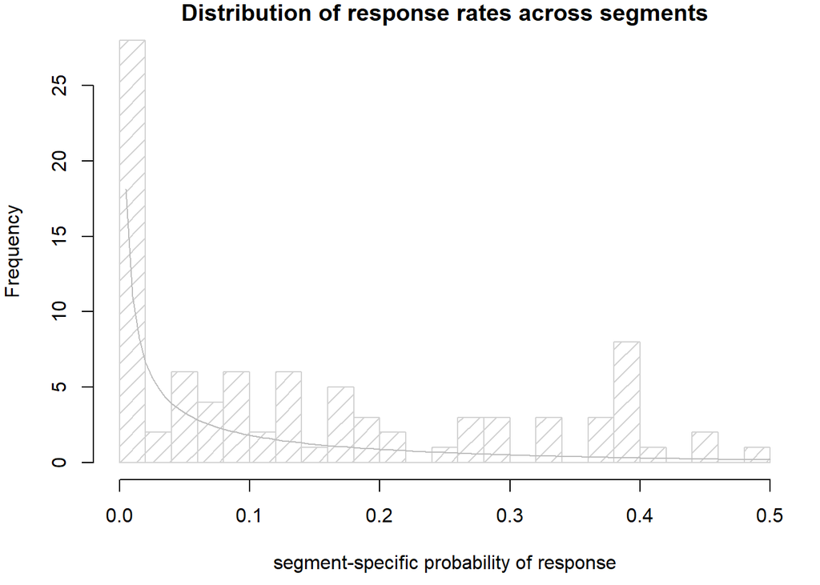

```r
par(mai=c(.9,.8,.2,.2))
hist(respRFM$resp_rate, density=10, breaks=20, main="Distribution of response rates across segments", xlab="segment-specific probability of response")
curve(dbeta(x, .3, 3), add = TRUE,  type="l", col="gray")
```

### Comprehension Check

> *Why use a beta distribution instead of a normal distribution?*

> [DISCUSS HERE]

### Empirical Bayes

We talked in Lecture 1 about a Bayesian approach with a prior. The prior could come from past knowledge or complete uncertainty. Now we introduce a third approach: we’re going to use the data to to choose the parameters of the prior distribution that fit the best. This approach is called **Empirical Bayes**.

We will fit the distribution of rates to the actual data. So our assumption here is really just the form of the distribution. The parameters of the distribution will be estimated directly from the data. (This is called Empirical Bayes estimation.)

More formally, we assume that $p_z$ comes from a common beta distribution where $a$ and $b$ are parameters we fit to the data (just as $\mu$ and $\sigma$ are parameters you fit in the normal distribution). $B(a,b)$ is an integration constant and is not important. This is the beta distribution.
$$f(p | a,b) = \frac{p^{a-1}
(1-p)^{b-1}}{B(a,b)}, \qquad a>0, b>0$$
The mean of the beta distrtion is $E[p|a,b]=\frac{a}{a+b}$. Here are some of the [shapes](https://shiny.stat.ncsu.edu/bjreich/Beta_PDF/) the beta distribution can take on.

Now to get the model for responses and the distribution of response rates, we have to sum up all the possible response rates and probabilities of them occuring that would have given rise to the responses. In other words we have to integrate the binomial response given its response rate over its beta distribution. We get the resulting model, the Beta-binomial model:
$$\begin{array}{ccl}
P(s_z|n_z, a, b)& = & \displaystyle \int P(s_z | p_z, n_z)
\; f(p_z|a,b) \; dp_z \\
& = & \displaystyle {n_z \choose s_z}
\frac{B(a+s_z,b+n_z-s_z)}{B(a,b)}
\end{array}$$

```r
#install.packages("VGAM")
library(VGAM)
fit <- vglm(cbind(respRFM$n_resp,respRFM$n_nonresp) ~ 1, betabinomialff, trace=TRUE)
```

```
## VGLM    linear loop  1 :  loglikelihood = -260.19283
## VGLM    linear loop  2 :  loglikelihood = -259.86438
## VGLM    linear loop  3 :  loglikelihood = -259.86068
## VGLM    linear loop  4 :  loglikelihood = -259.86066
## VGLM    linear loop  5 :  loglikelihood = -259.86066
```

```r
Coef(fit)
```

```
## shape1 shape2
##  0.493  3.113
```

```r
# make them a and b

a<-Coef(fit)[[1]]
b<-Coef(fit)[[2]]
```

Now that $p_z$ has a distribution, we no longer have an estimate. We can talk about its posterior mean, after observing $s_z$ responses for segment $z$ in the model:
$$\begin{array}{ccl}
E(p_z|s_z, n_z) & = & \displaystyle \frac{a+s_z}{a+b+n_z}\\
& = & \displaystyle \frac{s_z}{n_z} \left( \frac{n_z}{a+b+n_z}
\right) + \frac{a}{a+b} \left( \frac{a+b}{a+b+n_z} \right)
\end{array}$$
This shows exactly how much we rely on the individual segment estimate $\frac{s_z}{n_z}$ and the population response rate across segments $\frac{a}{a+b}$. The expressions in parentheses are weights that sum to 1. The more people mailed in each segment, the higher the weight $\left( \frac{n_z}{a+b+n_z} \right)$ relative to $a+b$, and therefore the more emphasis placed on the segment-specific response rate $\frac{s_z}{n_z}$. In that case there is not so much “shrinking to the mean.” On the other hand, if $n_z$ is small relative to $a+b$, the larger the weight $\left( \frac{a+b}{a+b+n_z} \right)$, and the more emphasis placed on the population mean, $\frac{a}{a+b}$.

```r
# posterior mean response rate
post_mean_resp<-(a+respRFM$n_resp)/(a+b+respRFM$n_mail)

# add this as column to respRFM
respRFM<-cbind(respRFM, post_mean_resp)

#order from lowest to greatest
respRFM<-respRFM %>% arrange((resp_rate))

head(respRFM)
```

```
##   RFMgroup n_resp n_nonresp n_mail resp_rate post_mean_resp
## 1      121      0        39     39         0        0.01157
## 2      122      0        48     48         0        0.00955
## 3      123      0        46     46         0        0.00994
## 4      124      0        45     45         0        0.01014
## 5      125      0        38     38         0        0.01185
## 6      131      0        43     43         0        0.01058
```

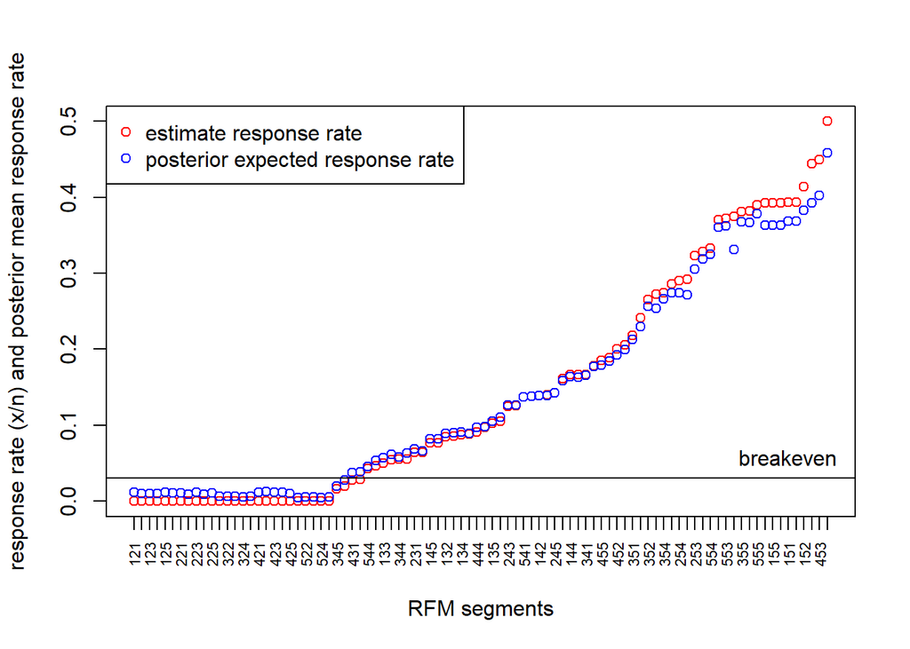

```r
plot(respRFM$resp_rate, xaxt="n",col="red",xlab="RFM segments",ylab="response rate (x/n) and posterior mean response rate")
points(respRFM$post_mean_resp, col='blue')
legend('topleft',legend=c("estimate response rate", "posterior expected response rate"),col=c("red","blue"), pch=1)
axis(1, at = 1:90, labels=respRFM$RFMgroup, cex.axis=0.7, las=2)
abline(h=brk)
text(85, brk, "breakeven", cex=1, pos=3, col="black")
```

The posterior mean shrinks (up or down) the response rate to the overall mean response across segments depending on how much data there is. The less data, the more shrinking.

Are there any switches we would make using the posterior mean rather than the actual mean to target segments?

```r
sum(respRFM$resp_rate>=brk)
```

```
## [1] 60
```

```r
sum(respRFM$post_mean_resp>=brk)
```

```
## [1] 62
```

Here’s an example of a segment that would not be targeted using the proportion responded but is targeted using the posterior mean.

```r
respRFM %>% filter(RFMgroup=="233")
```

```
##   RFMgroup n_resp n_nonresp n_mail resp_rate post_mean_resp
## 1      233      1        34     35    0.0286         0.0387
```

### RFM analysis with transaction data

As we mentioned in the beginning of class, one type of data is where a row is an order of a customer, i.e. a transaction. Then we need to calculate RFM by aggregating across transactions to the customer level. I’ll show a package, rfm, that does that for your here.

```r
library(rfm)
library(lubridate)
setwd("C:/Users/gknox/Dropbox/Customer Analytics/R notebooks/RFM & logistic")

cdNOW <- read.csv('./data/CDnow.txt', header=FALSE, sep = "")

colnames(cdNOW) <- c("CustomerID","InvoiceDate","Quantity","Amount")

cdNOW[10:20,]
```

```
##    CustomerID InvoiceDate Quantity Amount
## 10          4    19970101        2   29.3
## 11          4    19970118        2   29.7
## 12          4    19970802        1   15.0
## 13          4    19971212        2   26.5
## 14          5    19970101        2   29.3
## 15          5    19970114        1   14.0
## 16          5    19970204        3   38.9
## 17          5    19970411        3   45.5
## 18          5    19970531        3   38.7
## 19          5    19970616        2   26.1
## 20          5    19970722        2   28.1
```

I’ve loaded in data from CDNow, which we discussed in the lecture. Customer 4 in this data set is the same as customer 1 in the lecture.

The main function that does the analysis is rfm_table_order. You have to indicate an analysis date, which is beyond the last date of the dataset, otherwise you get negative values for recenecy. I set the analysis date as one day later than the max date in the data set.

```r
cdNOW$InvoiceDate <-ymd(cdNOW$InvoiceDate)
head(cdNOW)
```

```
##   CustomerID InvoiceDate Quantity Amount
## 1          1  1997-01-01        1   11.8
## 2          2  1997-01-12        1   12.0
## 3          2  1997-01-12        5   77.0
## 4          3  1997-01-02        2   20.8
## 5          3  1997-03-30        2   20.8
## 6          3  1997-04-02        2   19.5
```

```r
summary(cdNOW)
```

```
##    CustomerID     InvoiceDate            Quantity        Amount
##  Min.   :    1   Min.   :1997-01-01   Min.   : 1.0   Min.   :   0
##  1st Qu.: 5506   1st Qu.:1997-02-22   1st Qu.: 1.0   1st Qu.:  14
##  Median :11410   Median :1997-04-24   Median : 2.0   Median :  26
##  Mean   :11471   Mean   :1997-07-02   Mean   : 2.4   Mean   :  36
##  3rd Qu.:17273   3rd Qu.:1997-11-07   3rd Qu.: 3.0   3rd Qu.:  44
##  Max.   :23570   Max.   :1998-06-30   Max.   :99.0   Max.   :1286
```

```r
analysis_date <- lubridate::as_date("1998-07-01")

rfm_analysis<-rfm_table_order(cdNOW, customer_id = CustomerID, order_date = InvoiceDate, revenue = Amount, analysis_date)
rfm_analysis
```

```
## # A tibble: 23,570 x 9
##    customer_id date_most_recent recency_days transaction_count amount
##          <int> <date>                  <dbl>             <dbl>  <dbl>
##  1           1 1997-01-01                546                 1   11.8
##  2           2 1997-01-12                535                 2   89
##  3           3 1998-05-28                 34                 6  156.
##  4           4 1997-12-12                201                 4  100.
##  5           5 1998-01-03                179                11  386.
##  6           6 1997-01-01                546                 1   21.0
##  7           7 1998-03-22                101                 3  265.
##  8           8 1998-03-29                 94                 8  198.
##  9           9 1998-06-08                 23                 3   95.8
## 10          10 1997-01-21                526                 1   39.3
## # ... with 23,560 more rows, and 4 more variables: recency_score <int>,
## #   frequency_score <int>, monetary_score <int>, rfm_score <dbl>
```

(optional) How many people are in each RFM group, how much did they spend, and what RF combinations have a high spend?

```r
count<-aggregate(list(rfm_analysis$rfm$customer_id), by = list(rfm_analysis$rfm$rfm_score), FUN = "length")
avgM<-aggregate(list(rfm_analysis$rfm$amount), by = list(rfm_analysis$rfm$rfm_score), FUN = "mean")
rfm_tbl<-cbind(count, avgM[,2])
colnames(rfm_tbl) <- c("RFM segment","number customers","Avg. amount spent")

rfm_tbl
```

```
##    RFM segment number customers Avg. amount spent
## 1          111             1762              12.7
## 2          112             1244              24.4
## 3          113              824              44.4
## 4          114              360              82.5
## 5          115               53             202.5
## 6          131                1              11.8
## 7          132               64              26.7
## 8          133               93              44.8
## 9          134               79              88.8
## 10         135               25             233.9
## 11         143               13              51.0
## 12         144               11              86.1
## 13         145                6             261.1
## 14         154                2             121.5
```

[output cut: 58 more lines]